# My visual data story - The relationship between phone usage and Time spent exercising

## Daily Phone usage vs Exercise habits

This visual data story explores the relationship between daily phone usage and time spend on exercise. We collect data on daily phone usage (in hours) and daily exercise duration (in minutes) for 49 days. Age and Other factors that may influence exercise duration each day are also considered. However, since this data is solely collected from one individual’s observation (me), any patterns and insights obtained are not influenced by age. The dataset is stored in a data frame consisting of the following variables:

- **phone_usage**: Total time spent on the phone each day (in hours).
- **exercise_time**: Total time spent exercising each day (in minutes).
- **other_factors**: Categorical data representing external factors affecting exercise time.
- **age**: Age ranges of participants (categorical).
- **week_day**: Day of the week the observation was recorded.

## Phone Usage vs. Time Spent Exercising

First, let’s explore how my daily phone usage relates to the time I spent exercising.

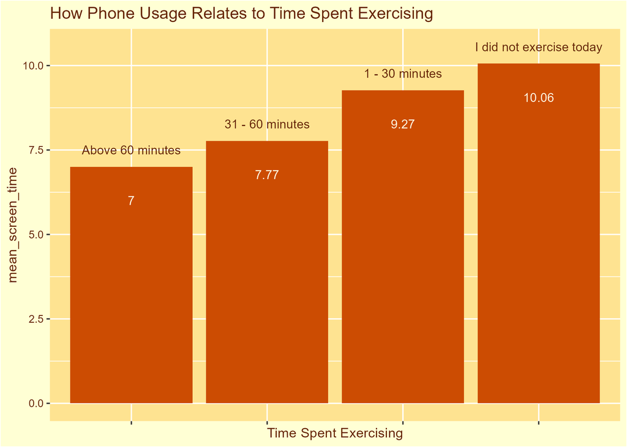

bar chart showing the relationship between phone usage and time spent exercising

This plot describes the relationship between my average daily screen time/phone usage and and how much time I spend exercising The x-axis categorises responses by the time spent on exercising within one day. The y-axis represents the mean screen time in hours.

There is a clear negative relationship between the phone usage/screen time and time spend on exercise. The responses from days when I did not exercise at all have the highest average screen time, 10.06 hours. In contrast, the days when I exercised the most ( above 60 minutes) have an average screen time of 7 hours, which is the lowest.

This suggests that phone usage and time spent exercising are linked, with one potentially influencing the other.

## Phone Usage Remains Consistent Across Weekdays

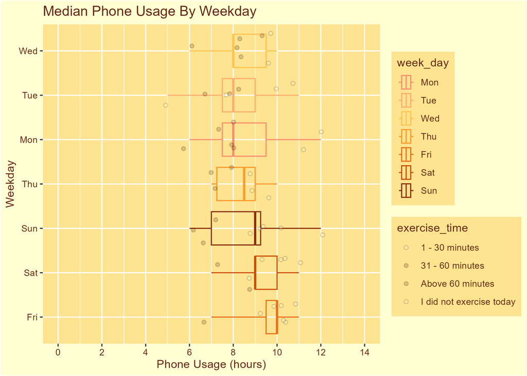

boxplot showing median phone usage by weekday

This plot shows my daily phone usage across different days of the week. The median phone usage stays relatively consistent between 8 and 10 hours. There’s no day on which my phone usage appears to be significantly greater or smaller than on other days, suggesting that the day of the week does not have a strong influence on how much time I spend on my phone.

Looking at the plot, we notice that the day with a slightly higher median phone usage has more observations from days when I exercised for less than 30 minutes, while the day with a lower median phone usage has more observations from days when I exercised for more than 30 minutes.

This supports the claim in the previous section.

## Is Time Spent Exercising Affected by Other Factors?

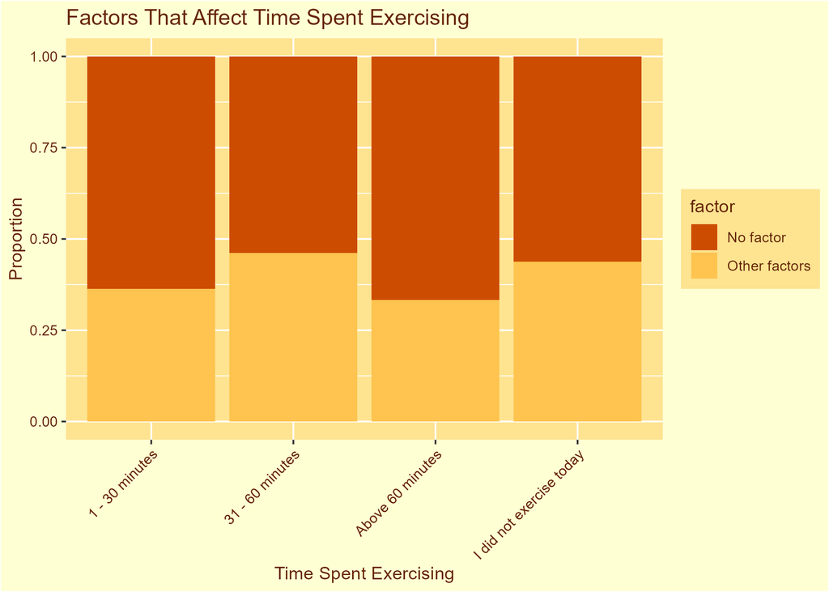

Stacked bar chart showing the proportion of days affected by “no other factor” versus ’some other factors

This plot shows that the proportions of days affected by other factors (illness, personal reasons, work or study commitments, weather) are relatively similar across all categories of exercise duration. This suggests that these external factors do not strongly determine the time I spend exercising. For example, even on days when I exercised for only 1–30 minutes or didn’t exercise at all, the influence of other factors is similar to days when I exercised above 30 minutes.

This suggests that the reduced exercise time on some days may not due to external circumstances but mainly due to my phone usage.

## Conclusion:

Overall, we have seen a relationship between phone usage and time spent on exercise. There’re also some evidence to rule out the possibility that other factors like the day of the week or external circumstances determine phone usage and exercise time, rather than the relationship between the two themselves.

The claim that “phone usage and time spent exercising are linked, with one potentially influencing the other” may therefore be valid.